# Emisiones de metano por Regiones y sectores económicos

# Introducción

## Fila 1 {data-heigth = 500}

### Sobre nuestra investigación

El gas metano es emitido a la atmósfera de forma natural por humedales, océanos, erupciones volcánicas y organismos como las termitas. Sin embargo, el 60% de las emisiones actuales son de origen antrópico.

El presente estudio de caso utiliza una base de datos de emisión de metano por países, regiones y fuentes de emisión (actividades económicas) de la Agencia Internacional de Energía (IEA por sus siglas en inglés) y una de los Indicadores de Desarrollo Mundiales desarrollados por el Banco Mundial. Se analizó un modelo de regresión multivariada para comprender la relación entre la magnitud de las emisiones por región y por sector económico y aquí se presenta un modelo de redes que facilite la visualización y comprensión de la relación entre las variables.

## Fila 2

### veces más energía calorífica que el dióxido de carbono

80

### de contribución al calentamiento global

30 %

### de las emisiones son antropogénicas

60 %

# Gráficos exploratorios

## Fila 1

### Emisiones por región.

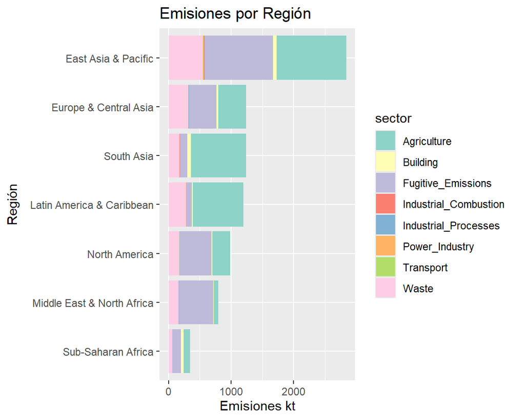

### Países más emisores

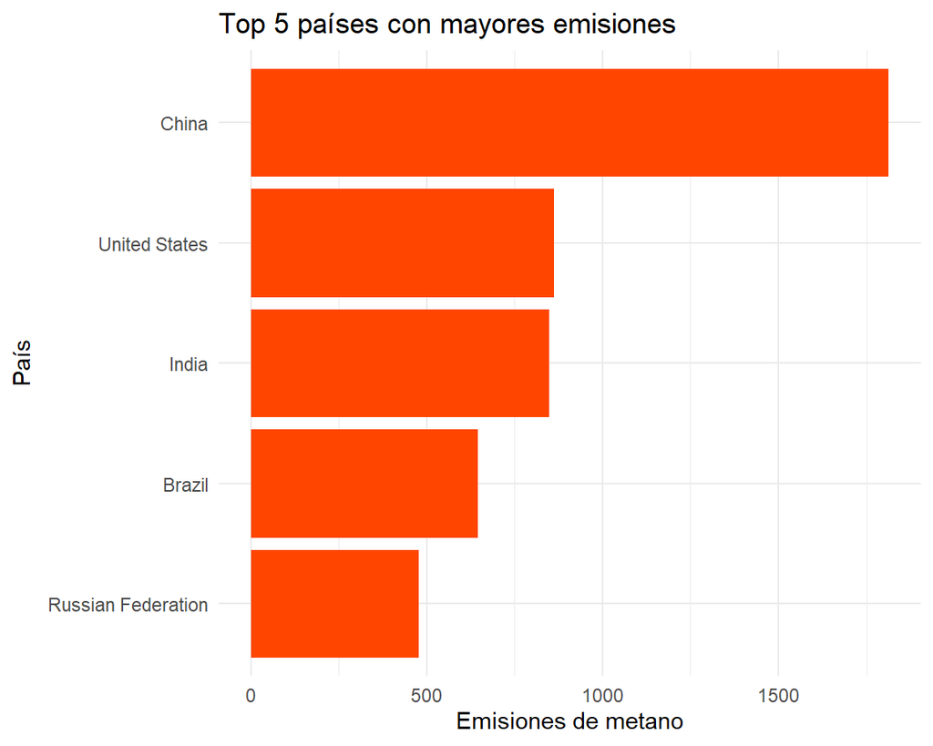

### Países menos emisores

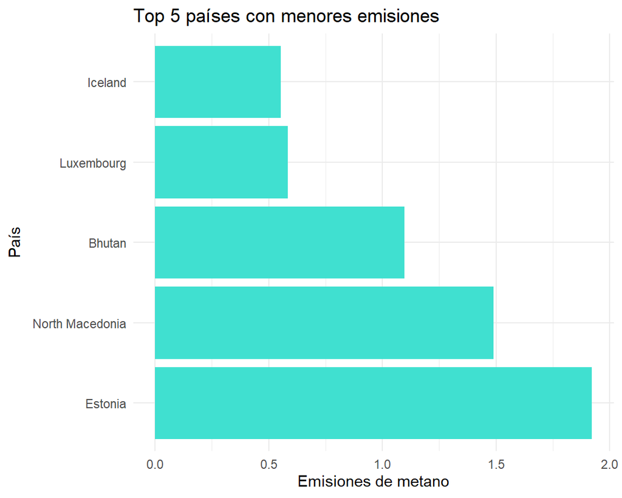